# Homework Problem Set 6

Keith Hickman

October 8, 2017

## Problem 1

## Trosset 7.7.1 a-e

1. Graph the empirical cdf of x. *I copied the values from the text into a csv format*

```r
ex7 <- read.table("c:/Users/khickman/Desktop/Personal/IUMSDS/StatsS520/Module6/ex7.csv")
data <- ex7
summary(data)
```

```
##        V1
##  Min.   :  92.0
##  1st Qu.: 225.0
##  Median : 462.0
##  Mean   : 494.6
##  3rd Qu.: 658.0
##  Max.   :1277.0
```

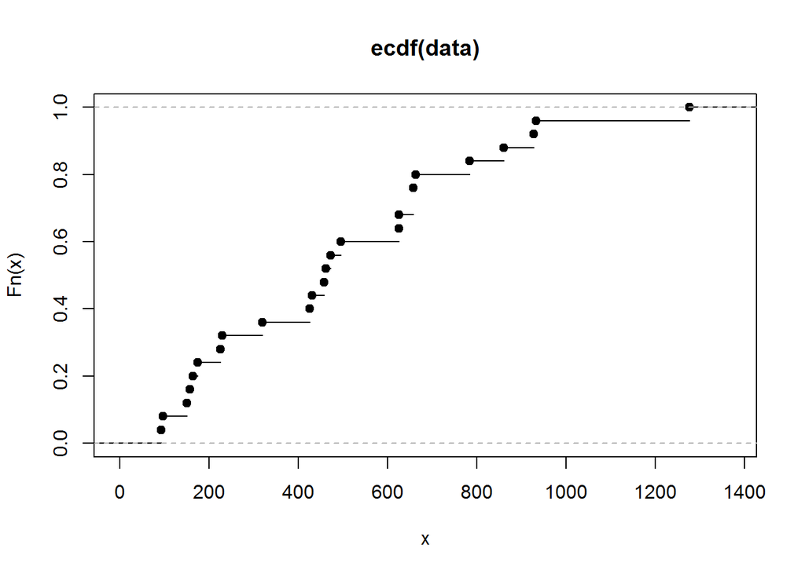

```r
data <- data[,1]
plot(ecdf(data))
```

2. Compute the plug-in estimates of the population mean and variance. **Mean:**

```r
lendata <- length(data)
meandata <- mean(data)
```

**Variance:**

```r
vardata <- (sum(data^2)/lendata) - meandata^2
vardata
```

```
## [1] 91078.72
```

3. Compute the plug-in estimates of the population median and interquartile range. **Median:**

```r
median(data)
```

```
## [1] 462
```

**IQR:**

```r
quant75 <- quantile(data,.75)

quant25 <- quantile(data,.25)

IQR <- quant75 - quant25
IQR
```

```
## 75%
## 433
```

```r
## or
iqr <- function(x)
  {q <- as.vector(quantile(x,probs=c(.25,.75)))
  return(q[2]-q[1])
  }
iqr(data)
```

```
## [1] 433
```

4. Compute the ratio of the plug-in estimate of the interquartile range to the square root of the plug-in estimate of the variance.

```r
sqrt(vardata)
```

```
## [1] 301.7925
```

```r
iqr(data) / (sqrt(vardata))
```

```
## [1] 1.434761
```

**The ratio of IQR to standard deviation is 1.43**

5. Construct a boxplot.

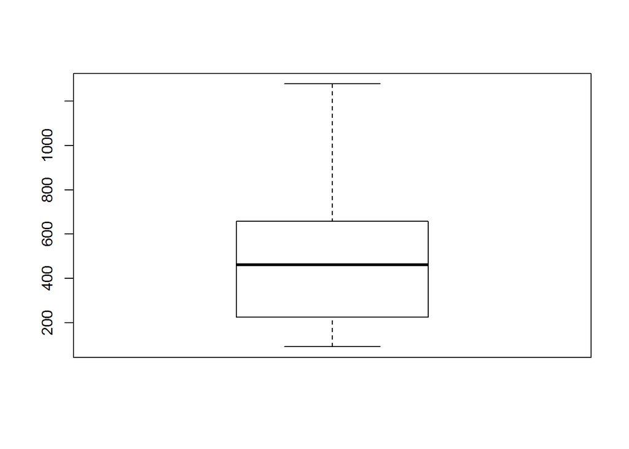

```r
boxplot(data)
```

**Trosset 7.7.2**

```r
pulse <- read.table("c:/Users/khickman/Desktop/Personal/IUMSDS/StatsS520/Module6/pulserates.csv")
summary(pulse)
```

```
##        V1
##  Min.   :52.00
##  1st Qu.:64.00
##  Median :72.00
##  Mean   :70.31
##  3rd Qu.:76.00
##  Max.   :92.00
```